# Regresión Logística usando PCA

Análisis sobre datos de calidad del vino.

Ignacio Ibarra https://github.com/Ignacio-Ibarra (Maestría en Data Mining & KDD (FCEyN-UBA))http://datamining.dc.uba.ar/datamining/  
2022-06-27

El presente trabajo analiza una [muestra](https://archive.ics.uci.edu/ml/datasets/wine+quality) de 6.497 registros, la cual reporta distintas variedades y calidades de vinos con sus respectivas características químicas. Se aplica PCA y Regresión Logística para predecir la variead de un vino dadas sus características fisico-químicas.

```r
#Cargo Paquetes
# install.packages("vtable")
# install.packages("distill")
# install.packages("tidyverse")
# install.packages("kableExtra")
# install.packages("rmarkdown")
# install.packages("reshape2")
# install.packages("gridExtra")
# install.packages("factoextra")
# install.packages("ggfortify")
# install.packages("ggpubr")
# install.packages("mlr")
require(mlr)
require(ggpubr)
require(ggfortify)
require(kableExtra)
require(vtable)
require(tidyverse)
require(readxl)
require(stringi)
require(stringr)
require(rmarkdown)
require(factoextra)
require(reshape2)
require(grid)
require(gridExtra)
#---------------------------
# Seteo theme para pĺots
theme <- theme(text = element_text(size=10),plot.title = element_text(size=12, face="bold.italic",
               hjust = 0.5), axis.title.x = element_text(size=10, face="bold", colour='black'),
               axis.title.y = element_text(size=10, face="bold"))
#----------------------------------------------------

#Cargo datasets y trabajo con features numéricas
df <- read_excel("./data/winequality.xlsx")

# #Muestra Balanceada
# var1 <- df[df$variedad==1,]
# var2 <- df[df$variedad==2,]
# set.seed(792)
# sampleo1 <- sample(1:nrow(var1), size=1000, replace = F)
# sampleo2 <- sample(1:nrow(var2), size=1000, replace = F)
# var1 <- var1[sampleo1,]
# var2 <- var2[sampleo2,]
#
# #Piso de nuevo la variable df
# df <- rbind(var1,var2)

#Pasamos a categóricas las variables calidad y variedad
df$cat.calidad <- factor(df$calidad,  ordered = TRUE)
df$variedad <- as.factor(df$variedad)
names(df) <- stringi::stri_trans_general(str = names(df), id = "Latin-ASCII")
names(df) <- stringr::str_replace_all(names(df), " ", "_")
```

# Análisis de Componentes Principales

Se realizó análisis de componentes principales sobre doce atributos, todos numéricos. A continuación se observa el biplot con todas las coordenadas de las primeras dos componentes principales.

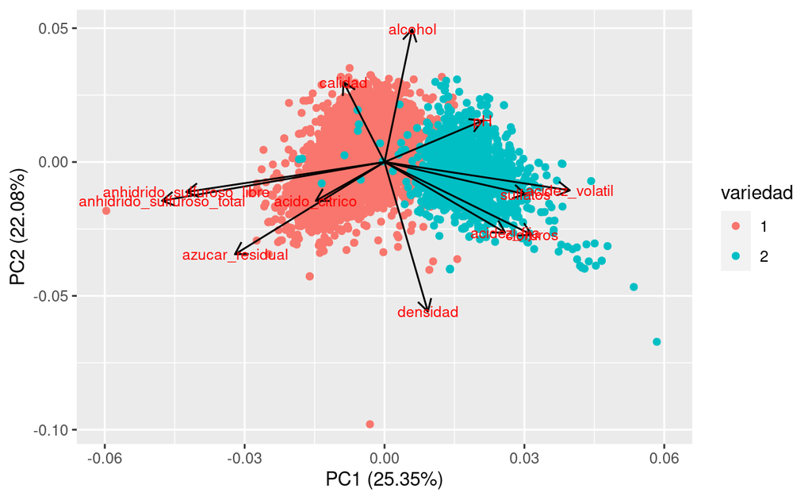

Figure 1: PCA: biplot

```r
num.cols<- unlist(lapply(names(df), function(x){
                          if (is.numeric(unlist(df[,x]))){return(x)}
                                                        }))
# num.cols <- num.cols[num.cols!="calidad"] #la columna calidad sigue siendo numérica no fue sacada dado que se usa más adelante nuevamente con otra transformación

dfnum <- df[,num.cols]
pca <- prcomp(dfnum, scale=T)

autoplot(pca,
         data = df,
         colour = 'variedad',
         loadings = TRUE,
         loadings.colour = 'black',
         loadings.label = TRUE,
         loadings.label.size = 3)+
  xlim(-0.06,0.06)
```

# Regresión logística $+$ PCA

```r
all.data <- as.data.frame(cbind(dfnum, variedad = df$variedad))

#train y test
set.seed(1409) # para asegurar reproducibilidad
dt = sort(sample(nrow(all.data), nrow(all.data)*.7))
datos_tr<-all.data[dt,]
datos_te<-all.data[-dt,]

# Se realiza el escalado/estandarización con ->  (x - mean(x)) / sd(x)

# Calculo media y sd de subconjunto de entrenamiento (train), y con esos datos hago el escalado del test. La idea de escalar el conjunto de test (prueba) utilizando datos solamente de train es para evitar el data leakeage.

# Hago escalado a mano del test set con media del training, y sd del training
for (k in 1:12){datos_te[,k]=(datos_te[,k]-mean(datos_tr[,k]))/sd(datos_tr[,k])}

# Hago automáticamente con la función scale, el escalado de training, y le vuelvo a sumar las columnas sex y diagnosis
datos_tr = as.data.frame(scale(datos_tr[,1:12]))
datos_tr$variedad <- all.data[dt,]$variedad

# chequeo el balance de las distintas clases de  la variable variedad en el conjunto de todos los datos, los datos de prueba y los datos de entramiento.
Entrenamiento <- table(datos_tr$variedad)
Prueba <- table(datos_te$variedad)
Total <- table(all.data$variedad)
kable(rbind(Entrenamiento, Prueba,Total), caption = "Pesos Clases en Train y Test")
```

Table 1: Pesos Clases en Train y Test

|  | 1 | 2 |
| --- | --- | --- |
| Entrenamiento | 3428 | 1119 |
| Prueba | 1470 | 480 |
| Total | 4898 | 1599 |

## Modelo

Obtengo los loadings de PCA con datos de training y mediante un simple producto de matrices obtengo las coordenadas de los datos de test expresadas mediante los loadings de los datos de train. Luego instancio el modelo, realizo entrenamiento y obtengo $\textit{accuracy}$ en el set de prueba.

```r
pca.train <- prcomp(datos_tr[,1:12], scale=T)
a = pca.train$rotation
pca.test <- data.matrix(datos_te[,1:12]) %*% data.matrix(a)

datos_tr <- data.frame(cbind(pca.train$x, variedad = datos_tr$variedad))
datos_te <- data.frame(cbind(pca.test, variedad = datos_te$variedad))
#-----------------------------------------
# Armo modelo de regresión logistica.
set.seed(1)
datos_tr$variedad <- as.factor(datos_tr$variedad)
datos_te$variedad <- as.factor(datos_te$variedad)
task = makeClassifTask(data = datos_tr, target = "variedad")
lrn = makeLearner("classif.logreg", predict.type = "prob")
mod_lr = mlr::train(lrn, task)
# Predicción en TEST
pred_lr= predict(mod_lr, newdata = datos_te)
acc_lg1 <- round(measureACC(as.data.frame(pred_lr)$truth, as.data.frame(pred_lr)$response),3)

acc_lg1
```

```
[1] 0.993
```

*Matriz de Confusión (poco confundida)*

```r
table(as.data.frame(pred_lr)$truth, as.data.frame(pred_lr)$response)
```

```
       1    2
  1 1462    8
  2    6  474
```

Esta es la razón por la cual la prediccion es tan buena. Usando los loadings de pca training logramos obtener datos en test cuyos fetaures tienen muy baja colinealidad.

```r
round(cor(datos_te[,1:12]),2)
```

```
       PC1   PC2   PC3   PC4   PC5   PC6   PC7   PC8   PC9  PC10
PC1   1.00  0.02 -0.02  0.04  0.03  0.01 -0.02  0.02  0.01 -0.07
PC2   0.02  1.00  0.01  0.06  0.05  0.01  0.04 -0.04 -0.07  0.02
PC3  -0.02  0.01  1.00 -0.01  0.03  0.03 -0.02 -0.02 -0.01  0.01
PC4   0.04  0.06 -0.01  1.00 -0.01  0.02 -0.03  0.03 -0.03  0.01
PC5   0.03  0.05  0.03 -0.01  1.00  0.01  0.07 -0.02 -0.08  0.04
PC6   0.01  0.01  0.03  0.02  0.01  1.00  0.00 -0.03 -0.05  0.03
PC7  -0.02  0.04 -0.02 -0.03  0.07  0.00  1.00  0.02 -0.04 -0.03
PC8   0.02 -0.04 -0.02  0.03 -0.02 -0.03  0.02  1.00  0.04 -0.03
PC9   0.01 -0.07 -0.01 -0.03 -0.08 -0.05 -0.04  0.04  1.00 -0.06
PC10 -0.07  0.02  0.01  0.01  0.04  0.03 -0.03 -0.03 -0.06  1.00
PC11  0.01  0.00 -0.02 -0.02 -0.02  0.02 -0.03 -0.01  0.03 -0.02
PC12  0.02  0.12  0.02  0.11  0.17  0.03  0.04 -0.03 -0.16  0.08
      PC11  PC12
PC1   0.01  0.02
PC2   0.00  0.12
PC3  -0.02  0.02
PC4  -0.02  0.11
PC5  -0.02  0.17
PC6   0.02  0.03
PC7  -0.03  0.04
PC8  -0.01 -0.03
PC9   0.03 -0.16
PC10 -0.02  0.08
PC11  1.00 -0.03
PC12 -0.03  1.00
```